# Custome Survival Analysis

Navankur Verma - navankurverma@gmail.com

08/07/2020

## Dataset:

Telecom companies are very interested in when customers leave their company (this is called churn). A dataset made publicly available by IBM on customer churn from a telecom company is available in the `BDgraph` R package and are called churn. The dataset contains the length of time the customer was with the company (`Account.Length`), whether they churned (`Churn`) and a number of other covariates for 3333 customers.

## Kaplan-Meier estimate

```r
library(BDgraph)
library(survival)

data("churn")
str(churn)
```

```
## 'data.frame':    3333 obs. of  20 variables:
##  $ State         : Factor w/ 51 levels "AK","AL","AR",..: 17 36 32 36 37 2 20 25 19 50 ...
##  $ Account.Length: int  128 107 137 84 75 118 121 147 117 141 ...
##  $ Area.Code     : int  415 415 415 408 415 510 510 415 408 415 ...
##  $ Int.l.Plan    : Factor w/ 2 levels "no","yes": 1 1 1 2 2 2 1 2 1 2 ...
##  $ VMail.Plan    : Factor w/ 2 levels "no","yes": 2 2 1 1 1 1 2 1 1 2 ...
##  $ VMail.Message : int  25 26 0 0 0 0 24 0 0 37 ...
##  $ Day.Mins      : num  265 162 243 299 167 ...
##  $ Day.Calls     : int  110 123 114 71 113 98 88 79 97 84 ...
##  $ Day.Charge    : num  45.1 27.5 41.4 50.9 28.3 ...
##  $ Eve.Mins      : num  197.4 195.5 121.2 61.9 148.3 ...
##  $ Eve.Calls     : int  99 103 110 88 122 101 108 94 80 111 ...
##  $ Eve.Charge    : num  16.78 16.62 10.3 5.26 12.61 ...
##  $ Night.Mins    : num  245 254 163 197 187 ...
##  $ Night.Calls   : int  91 103 104 89 121 118 118 96 90 97 ...
##  $ Night.Charge  : num  11.01 11.45 7.32 8.86 8.41 ...
##  $ Intl.Mins     : num  10 13.7 12.2 6.6 10.1 6.3 7.5 7.1 8.7 11.2 ...
##  $ Intl.Calls    : int  3 3 5 7 3 6 7 6 4 5 ...
##  $ Intl.Charge   : num  2.7 3.7 3.29 1.78 2.73 1.7 2.03 1.92 2.35 3.02 ...
##  $ CustServ.Calls: int  1 1 0 2 3 0 3 0 1 0 ...
##  $ Churn         : Factor w/ 2 levels "False","True": 1 1 1 1 1 1 1 1 1 1 ...
```

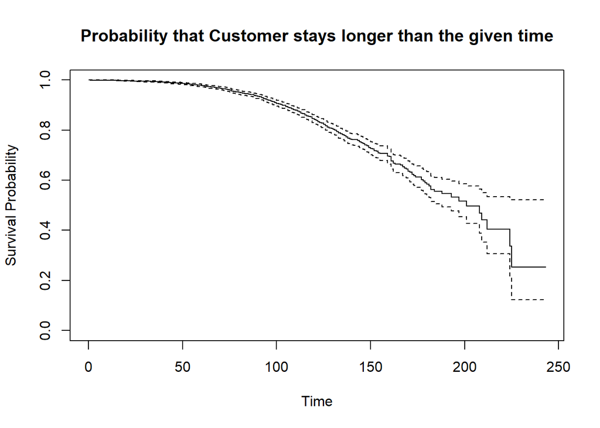

```r
#churn column is factor with 2 levels.
#In R, the levels start from 1, i.e. "False" is 1 and "True" is 2.
#To make 'Surv' object we need events in form of 0s (Survived) and 1s (Churned)
#So converting "True" to 1 for denoting customer churned and 0 otherwise.

churn$Churn <- ifelse(churn$Churn == "True", 1, 0)
target <- Surv(time = churn$Account.Length, event = churn$Churn)
fit <- survfit(target~1,se=TRUE)
plot(fit, xlab = "Time", ylab = "Survival Probability",
     main = "Probability that Customer stays longer than the given time")
```

## Median time to Churn

```r
#Median time to churn:
print(fit)
```

```
## Call: survfit(formula = target ~ 1, se = TRUE)
##
##       n  events  median 0.95LCL 0.95UCL
##    3333     483     201     188      NA
```

Median time to churn is 201.

## Cox proportional model

```r
library(SurvRegCensCov)
fit1 <- coxph(Surv(Account.Length,Churn)~ .,data=churn)
summary(fit1, conf.int=FALSE)
```

```
## Call:
## coxph(formula = Surv(Account.Length, Churn) ~ ., data = churn)
##
##   n= 3333, number of events= 483
##
##                      coef  exp(coef)   se(coef)      z Pr(>|z|)
## StateAL         3.727e-01  1.452e+00  6.815e-01  0.547 0.584509
## StateAR         7.263e-01  2.067e+00  6.578e-01  1.104 0.269536
## StateAZ         3.591e-01  1.432e+00  7.679e-01  0.468 0.640011
## StateCA         1.501e+00  4.484e+00  6.710e-01  2.236 0.025333 *
## StateCO         3.684e-01  1.445e+00  6.714e-01  0.549 0.583169
## StateCT         9.994e-01  2.717e+00  6.487e-01  1.541 0.123376
## StateDC         5.992e-01  1.821e+00  7.352e-01  0.815 0.415027
## StateDE         9.039e-01  2.469e+00  6.734e-01  1.342 0.179495
## StateFL         6.055e-01  1.832e+00  6.818e-01  0.888 0.374456
## StateGA         7.639e-01  2.147e+00  6.832e-01  1.118 0.263471
## StateHI        -1.553e-01  8.562e-01  8.200e-01 -0.189 0.849830
## StateIA         6.270e-01  1.872e+00  8.220e-01  0.763 0.445642
## StateID         9.225e-01  2.516e+00  6.724e-01  1.372 0.170049
## StateIL         2.504e-01  1.285e+00  7.335e-01  0.341 0.732838
## StateIN         8.284e-01  2.290e+00  6.709e-01  1.235 0.216887
## StateKS         9.738e-01  2.648e+00  6.441e-01  1.512 0.130580
## StateKY         1.377e+00  3.965e+00  6.829e-01  2.017 0.043688 *
## StateLA         4.333e-01  1.542e+00  7.687e-01  0.564 0.572958
## StateMA         1.335e+00  3.802e+00  6.545e-01  2.040 0.041311 *
## StateMD         9.443e-01  2.571e+00  6.314e-01  1.496 0.134760
## StateME         1.257e+00  3.515e+00  6.487e-01  1.938 0.052649 .
## StateMI         1.252e+00  3.497e+00  6.344e-01  1.973 0.048456 *
## StateMN         5.042e-01  1.656e+00  6.498e-01  0.776 0.437808
## StateMO         4.839e-01  1.622e+00  6.955e-01  0.696 0.486547
## StateMS         1.210e+00  3.353e+00  6.414e-01  1.886 0.059262 .
## StateMT         1.612e+00  5.013e+00  6.418e-01  2.512 0.012010 *
## StateNC         1.687e-01  1.184e+00  6.618e-01  0.255 0.798794
## StateND         1.417e-01  1.152e+00  7.112e-01  0.199 0.842124
## StateNE         3.729e-01  1.452e+00  7.373e-01  0.506 0.613038
## StateNH         1.024e+00  2.784e+00  6.713e-01  1.525 0.127203
## StateNJ         1.453e+00  4.275e+00  6.297e-01  2.307 0.021041 *
## StateNM         3.356e-01  1.399e+00  7.127e-01  0.471 0.637719
## StateNV         1.187e+00  3.278e+00  6.396e-01  1.856 0.063450 .
## StateNY         7.184e-01  2.051e+00  6.377e-01  1.127 0.259918
```

[output cut: 25 more lines]

```
## Eve.Charge     -3.759e+00  2.332e-02  1.665e+01 -0.226 0.821364
## Night.Mins     -3.205e-01  7.258e-01  7.682e-01 -0.417 0.676546
## Night.Calls     1.513e-03  1.002e+00  2.457e-03  0.616 0.537914
## Night.Charge    7.186e+00  1.320e+03  1.707e+01  0.421 0.673777
## Intl.Mins      -4.607e+00  9.980e-03  4.510e+00 -1.021 0.307019
## Intl.Calls     -7.837e-02  9.246e-01  2.179e-02 -3.596 0.000323 ***
## Intl.Charge     1.724e+01  3.081e+07  1.670e+01  1.032 0.301906
## CustServ.Calls  3.318e-01  1.393e+00  2.947e-02 11.257  < 2e-16 ***
## ---
## Signif. codes:  0 '***' 0.001 '**' 0.01 '*' 0.05 '.' 0.1 ' ' 1
##
## Concordance= 0.786  (se = 0.011 )
## Likelihood ratio test= 523.6  on 67 df,   p=<2e-16
## Wald test            = 508.3  on 67 df,   p=<2e-16
## Score (logrank) test = 566.6  on 67 df,   p=<2e-16
```

- `Int.l.Plan`, `VMail.Message` & `CustServ.Calls` have a positive coefficients making Hazard Ratios ($exp(\beta_{j})$) greater than 1 for each of them, i.e. hazard function increases faster with time and chances of Survival are reduced quickly. The decrease in fastest when the `Int.l.Plan = yes` (HR=3.77) as compared to when customer does not have a International plan and slowest for a unit increase of `VMail.Message` count (HR=1.049).
- The `VMail.Plan` & `Intl.Calls` has negative coefficients making HR less than 1 i.e. they reduce chances of customer churning out. In other words, having a Voice Mail Plan active increases chance of customer staying for long duration of time as compared to when they don’t have a Voice mail plan. And the hazard ratio is 0.09 in case of Voice Mail and 0.9 in case of International Calls, which means that hazard reduces faster when customer has Active Voice mail as compared to a unit increase of International Calls.

It can be shown using the Survival Function plot that how these covariates affect chances of customer churn, by running model on data which is filtered based on covariates (filtering here based on one covariate from both the positive and negative coefficient, `Int.l.Plan` from positive set & `VMail.Plan` from negative set):

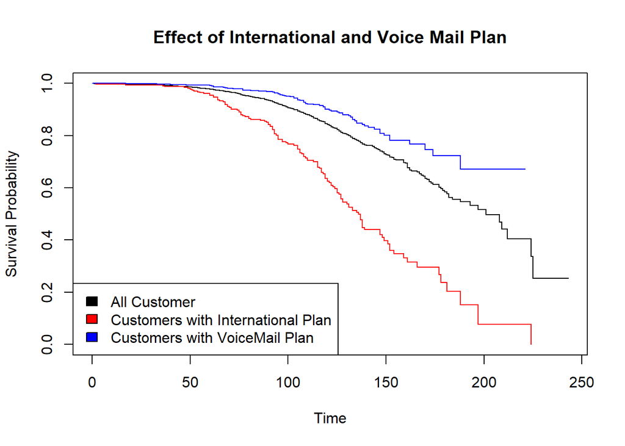

```r
plot(survfit(Surv(Account.Length, Churn)~1, se=FALSE, data = churn),
     main = "Effect of International and Voice Mail Plan",
     xlab = "Time", ylab = "Survival Probability")
lines(survfit(Surv(Account.Length, Churn)~1,se=FALSE,
              data = churn[churn$Int.l.Plan == "yes",]), col = "red")
lines(survfit(Surv(Account.Length, Churn)~1, se=FALSE,
              data = churn[churn$VMail.Plan == "yes",]), col = "blue")
legend("bottomleft", legend = c("All Customer",
                                "Customers with International Plan",
                                "Customers with VoiceMail Plan"),
       fill = c("black","red","blue"))
```

From the filtered data, it is clear that if customers have international plans active (red) then chances of survival reduces quickly whereas it increases if customers have Voice Mail plan active (blue).

Instead of keeping all the variables, the covariates which did not gave significant coefficients can be removed and CPH model can be built with remaining ones:

```r
fit2 <- coxph(Surv(Account.Length,Churn)~ State + Int.l.Plan + VMail.Plan +
                      VMail.Message + CustServ.Calls + Intl.Calls,
              data=churn)
summary(fit2, conf.int = FALSE)
```

```
## Call:
## coxph(formula = Surv(Account.Length, Churn) ~ State + Int.l.Plan +
##     VMail.Plan + VMail.Message + CustServ.Calls + Intl.Calls,
##     data = churn)
##
##   n= 3333, number of events= 483
##
##                    coef exp(coef) se(coef)      z Pr(>|z|)
## StateAL         0.31908   1.37586  0.67985  0.469 0.638826
## StateAR         0.89426   2.44553  0.65397  1.367 0.171491
## StateAZ         0.37155   1.44998  0.76534  0.485 0.627345
## StateCA         1.60542   4.97994  0.66718  2.406 0.016115 *
## StateCO         0.72036   2.05518  0.66710  1.080 0.280214
## StateCT         0.97550   2.65248  0.64590  1.510 0.130972
## StateDC         0.44690   1.56345  0.73075  0.612 0.540827
## StateDE         0.66655   1.94751  0.66964  0.995 0.319545
## StateFL         0.57978   1.78565  0.67728  0.856 0.391970
## StateGA         0.80479   2.23622  0.67845  1.186 0.235540
## StateHI        -0.08411   0.91933  0.81743 -0.103 0.918044
## StateIA         0.69238   1.99847  0.81833  0.846 0.397502
## StateID         0.85082   2.34156  0.66884  1.272 0.203345
## StateIL         0.38606   1.47117  0.73083  0.528 0.597331
## StateIN         1.02793   2.79528  0.66819  1.538 0.123956
## StateKS         1.21899   3.38375  0.64120  1.901 0.057289 .
## StateKY         1.40540   4.07716  0.67865  2.071 0.038371 *
## StateLA         0.41127   1.50873  0.76519  0.537 0.590944
## StateMA         1.35642   3.88229  0.65187  2.081 0.037451 *
## StateMD         1.24238   3.46386  0.62719  1.981 0.047605 *
## StateME         1.43845   4.21418  0.64209  2.240 0.025075 *
## StateMI         1.17525   3.23894  0.62980  1.866 0.062032 .
## StateMN         0.84210   2.32123  0.63677  1.322 0.186015
## StateMO         0.64795   1.91161  0.69032  0.939 0.347926
## StateMS         1.06571   2.90290  0.63761  1.671 0.094640 .
## StateMT         1.72729   5.62541  0.63769  2.709 0.006755 **
## StateNC         0.75112   2.11937  0.65186  1.152 0.249210
## StateND         0.29832   1.34759  0.70742  0.422 0.673247
## StateNE         0.56233   1.75475  0.73120  0.769 0.441863
## StateNH         1.13336   3.10607  0.66731  1.698 0.089430 .
## StateNJ         1.73661   5.67809  0.62567  2.776 0.005510 **
## StateNM         0.39038   1.47755  0.70856  0.551 0.581666
```

[output cut: 15 more lines]

```
## StateWI         0.45497   1.57613  0.69115  0.658 0.510359
## StateWV         0.73128   2.07773  0.65901  1.110 0.267147
## StateWY         0.46474   1.59160  0.66742  0.696 0.486229
## Int.l.Planyes   1.38037   3.97638  0.10769 12.818  < 2e-16 ***
## VMail.Planyes  -1.88438   0.15192  0.48479 -3.887 0.000101 ***
## VMail.Message   0.03859   1.03934  0.01509  2.556 0.010575 *
## CustServ.Calls  0.31473   1.36989  0.02902 10.847  < 2e-16 ***
## Intl.Calls     -0.06484   0.93721  0.02119 -3.060 0.002210 **
## ---
## Signif. codes:  0 '***' 0.001 '**' 0.01 '*' 0.05 '.' 0.1 ' ' 1
##
## Concordance= 0.733  (se = 0.013 )
## Likelihood ratio test= 367.3  on 55 df,   p=<2e-16
## Wald test            = 378.2  on 55 df,   p=<2e-16
## Score (logrank) test = 424  on 55 df,   p=<2e-16
```

Although the Concordance of this model reduces but it still predicts time-to-churn better than by simple random chance. As it has 12 less number of coefficients to estimate so making it a parsimonious model.

## Conclusion

Based on the given data, time to churn increases if customer has higher number of international calls or has a active Voice Mail plan whereas it decreases if customer has higher number of Voice Mail messages or higher number of Customer Service Calls or has an active International Plan.  
In general it makes sense, as for instance a customer who has higher number of voice messages is most likely to stop the service as they are not using it a lot and hence getting higher number of voice mails or a customer calling to customer service frequently would generaly mean they are not satisfied with service so they are more likely to opt out.